# CS109B Lab 3: Bayes Models

# Overview

There are three “levels” so to speak at which you can perform a Bayesian analysis in R.

1. You can perform simple analyses using distribution, math, and simulation functions.
2. You can use packages providing interfaces to pre-coded standard models.
3. You can use R as an interface to a general purpose MCMC environment.

Level 1 is good for learning basic Bayesian principles and for relatively simple analyses. Level 2 is good for fitting Bayesian versions of many models you are probably familiar with in a frequentest context. Finally, Level 3 is good for more complex analyses for which the full power and flexibility of a MCMC approach is needed.

In this lab session we’ll look at Bayesian analyses at each of these levels. But first…

## Distribution functions in R

Bayesian data analysis requires specifying prior distributions for the parameters in the model, then computing and analyzing posterior distributions.

Base *R* (specifically the `stats` package) provides

```
      Density, cumulative distribution function, quantile function and
      random variate generation for many standard probability
      distributions
```

Refer to `?Distributions` for more information. Additional distribution functions are available in various R packages.

You can read about the properties of various distributions, but if you’re a visual learner like me it can be useful to graph properties of a distribution at varying parameter values to get an intuitive feel for how the distribution behaves. For example, if we are not familiar with the `beta` distribution:

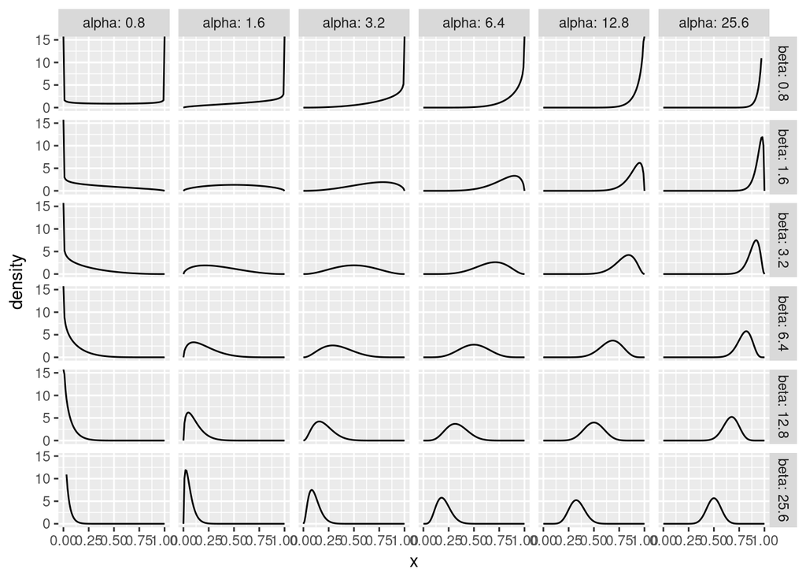

```r
shapes <- round(2^(3:8)/10, digits = 2)
x <- seq(0, 1, by = 0.01)

## all combinations of x, alpha, and beta
beta_d <- expand.grid(x = x,
                      alpha = shapes,
                      beta = shapes)

## split the data by alpha and beta, calculate density, then re-assemble (rbind).
beta_d <- do.call(rbind,
                  lapply(split(beta_d, beta_d[c("alpha", "beta")]),
                         function(data) {
                             data.frame(data,
                                        density = dbeta(data$x,
                                                        unique(data$alpha),
                                                        unique(data$beta)))
                         }))

library(ggplot2)

ggplot(beta_d, aes(x = x, y = density)) +
    geom_line() +
    facet_grid(beta ~ alpha, labeller = label_both) +
    scale_y_continuous(limits = c(0, 15))
```

# Simple analysis of proportions

*The lady tasting tea* is a classic in the statistic literature. The basic premise is that a lady claims to be able to tell if milk or tea was added to a cup first. Variations of the basic idea have appeared in statistics texts ever since the original reported in R. Fisher’s *The Design of Experiments* (1935). In most descriptions of the experiment the lady correctly identifies 8/8 cups of tea. What, in a Bayesian framework, does that tell us?

We can work it out using basic distribution statistics.

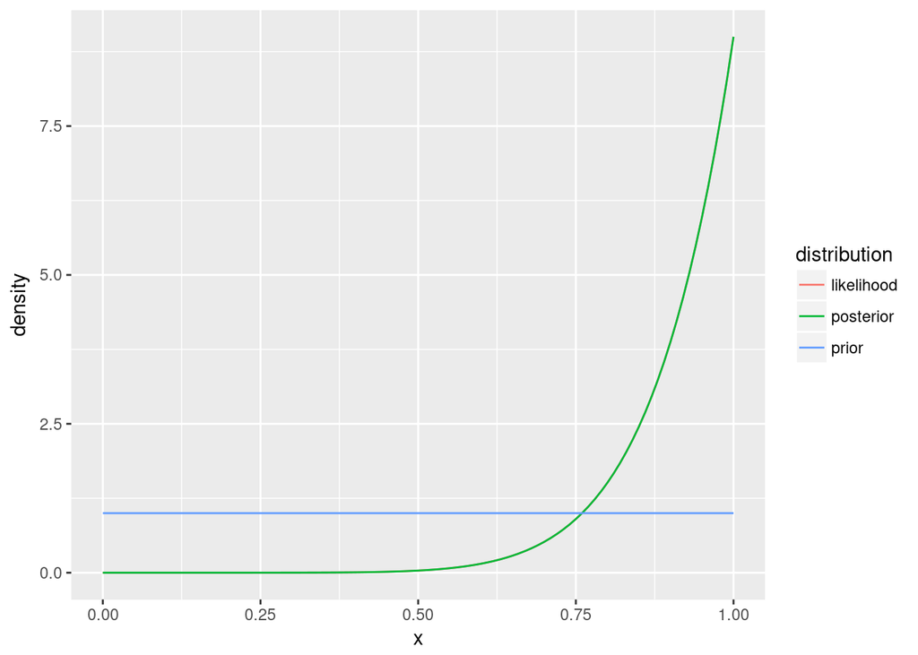

```r
## Obseved data
obs <- c(1, 1, 1, 1, 1, 1, 1, 1)
obs.count <- table(factor(obs, levels = c("0", "1")))

## Possible values of the unknown parameter
x <- (0:100)/100

## priors, likelihood, and posterior expressed as beta distribution parameters
prior_alpha <- prior_beta <- 1 ## dbeta(x, 1, 1) == dunif(x)
likelihood_alpha <- obs.count["1"] + 1
likelihood_beta <- obs.count["0"] + 1
posterior_alpha <- obs.count["1"] + prior_alpha
posterior_beta <- obs.count["0"] + prior_beta

p_tea1 <- data.frame(x = x, # possible values of our unobserved parameter theta
                     prior = dbeta(x, prior_alpha, prior_beta), # uniformative prior (does this make sense?)
                     likelihood = dbeta(x, # x^8*(1-x)^0 scaled to match prior
                                        likelihood_alpha,
                                        likelihood_beta),
                     posterior = dbeta(x, # since the prior is uninformative the posterior distribution is the likelihood
                                       posterior_alpha,
                                       posterior_beta))

library(tidyr)

p_tea1 <- gather(p_tea1,
                key = "distribution",
                value = "density",
                -x)

library(ggplot2)

ggplot(p_tea1,
       mapping = aes(x = x, y = density, color = distribution)) +
    geom_line()
```

## Does an uninformative prior make sense?

By specifying a uniform distribution we are saying that before seeing the data $\theta$ has equal probability of being any value between zero and 1. But that doesn’t seem quite right. Even if she can not tell the difference, the lady is likely to get some right. Perhaps before seeing the data we expect the median outcome to be 4/8, and that we are pretty confident about that. We can include this prior information in the analysis using a beta distribution.

The LearnBayes package has a utility for choosing a beta distribution that matches our prior beliefs.

```r
##  install.packages("LearnBayes")
library(LearnBayes)

prior_shape <- beta.select(list(p = .5, x = .5), # middle of the distribution is .5
                           list(p = .95, x = .7)) # 95th percentile is .7

## this is the beta distribution with mdeian = .5 and 95th percentile = .7
prior_shape
```

```
## [1] 8 8
```

We can use that information to calculation the posterior distribution again, incorporating this prior information.

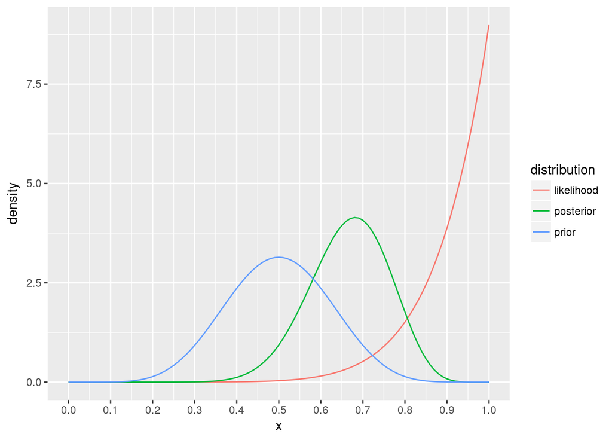

```r
prior_alpha <- prior_shape[1]
prior_beta <- prior_shape[1]
likelihood_alpha <- obs.count["1"] + 1
likelihood_beta <- obs.count["0"] + 1
posterior_alpha <- obs.count["1"] + prior_alpha
posterior_beta <- obs.count["0"] + prior_beta

p_tea2 <- data.frame(x = x,
                     prior = dbeta(x, prior_alpha, prior_beta),
                     likelihood = dbeta(x, # x^8*(1-x)^0 scaled to match prior
                                        likelihood_alpha,
                                        likelihood_beta),
                     posterior = dbeta(x,
                                       posterior_alpha,
                                       posterior_beta))

p_tea2 <- gather(p_tea2,
                 key = "distribution",
                 value = "density",
                 -x)

ggplot(p_tea2,
       mapping = aes(x = x, y = density, color = distribution)) +
    geom_line() +
    scale_x_continuous(breaks = seq(0.0, 1.0, by = 0.1))
```

## Analyzing the posterior distribution

Once the posterior distribution has been obtained it can be analyzed to obtain expected parameter values and other summary statistics. For the beta distribution we can calculate these values analytically:

```r
theta_summary1 <- c(mode = (posterior_alpha - 1/3) /
                           (posterior_alpha + posterior_beta - 1),
                    median = (posterior_alpha - 1/3) /
                             (posterior_alpha + posterior_beta - (2/3)))

theta_summary1
```

```
##    mode.1  median.1
## 0.6811594 0.6714286
```

A useful and general alternative is to simulate a sample from the distribution and analyze the simulated values:

```r
theta <- rbeta(1000000,
               posterior_alpha,
               posterior_beta)

Mode <- function(x) {
    dx <- density(x)
    dx$x[which.max(dx$y)]
}

theta_summary2 <- c(mode = Mode(theta),
                    median = median(theta),
                    lq = quantile(theta, .025),
                    uq = quantile(theta, 0.975),
                    mean = mean(theta),
                    var = var(theta))
theta_summary2
```

```
##        mode      median     lq.2.5%    uq.97.5%        mean         var
## 0.678288977 0.671004478 0.470689732 0.836188825 0.666396029 0.008893692
```

# Your Turn: Probability of a Purchase

Suppose that you run a website selling cat pajamas. You would like to calculate the probability that your star salesperson closes a sale. Over the course of a day you have 50 visitors, 5 of whom make a purchase.

1. Choose and define an uninformative prior distribution for the parameter in your model.

```r
x <- seq(.01, 1, by = .01)
prior <- dunif(x) ## same as dbeta(x, 1, 1)
```

2. Construct a likelihood function based on the observed 5/50 successes.

```r
sale <- c(rep(1, 5), rep(0, 45))
sale.count <- table(sale)

likelihood  <- dbeta(x, ## rescaled x^5*(1-x)^45
                     sale.count["1"] + 1,
                     sale.count["0"] + 1)
```

3. Calculate the posterior distribution of the parameter.

```r
posterior <- dbeta(x, sale.count["1"] + 1, sale.count["0"] + 1)
```

4. Calculate the expected value of the parameter.

```r
theta_sim <- rbeta(1000000, sale.count["1"]+1, sale.count["0"]+1)

mean(theta_sim)
```

```
## [1] 0.1154332
```

5. (Advanced) Plot the likelihood function and the prior and posterior distributions to see visually how we updated our beliefs about the probability based on the data.

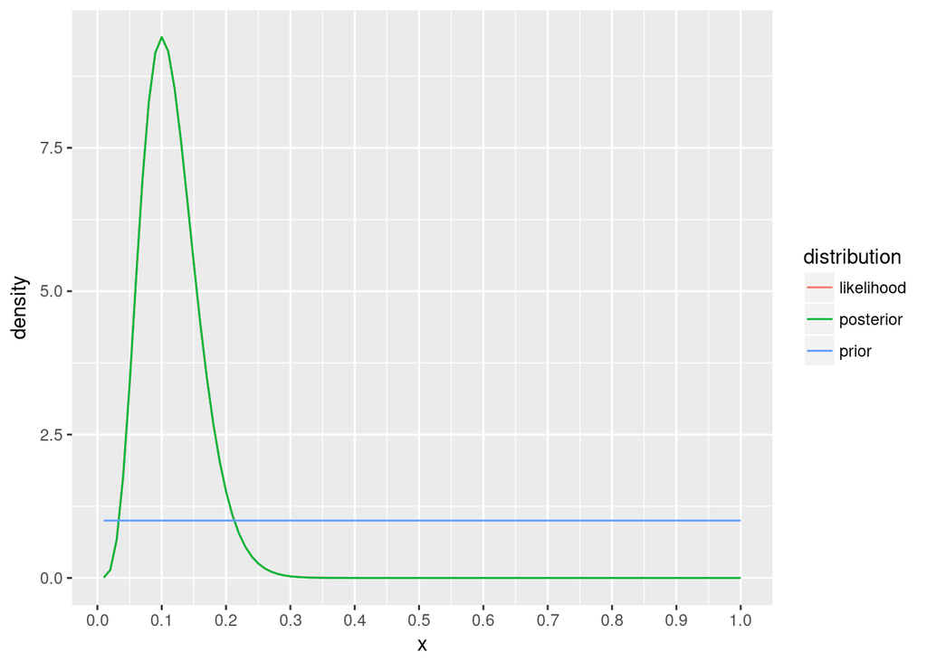

```r
library(ggplot2)
library(tidyr)
sales.dist <- gather(data.frame(x = x,
                                prior = prior,
                                likelihood = likelihood,
                                posterior = posterior),
                     key = "distribution",
                     value = "density",
                     -x)

ggplot(sales.dist,
       mapping = aes(x = x, y = density, color = distribution)) +
    geom_line() +
    scale_x_continuous(breaks = seq(0.0, 1.0, by = 0.1))
```

6. (Advanced) Fit a logistic regression predicting sales (this is an intercept-only model) and compare the results to those obtained from the Bayesian analysis.

```r
m <- glm(sale ~ 1, data = data.frame(sale = sale), family = binomial())
pred <- predict(m, newdata = data.frame(sale = 1), type = "response", se.fit = TRUE)
c(expected = pred$fit,
  lwr.95 = pred$fit - pred$se.fit*1.96,
  upr.95 = pred$fit + pred$se.fit*1.96)
```

```
## expected.1   lwr.95.1   upr.95.1
##  0.1000000  0.0168511  0.1831489
```

# Classification example

A classic classification example is the spam filter. I’ve made up some data based on https://archive.ics.uci.edu/ml/machine-learning-databases/spambase/ that we can use to illustrate.

```r
spam <- read.csv("http://tutorials.iq.harvard.edu/example_data/spam.csv")
str(spam)
```

```
## 'data.frame':    4601 obs. of  22 variables:
##  $ spam: Factor w/ 2 levels "email","spam": 2 2 2 2 2 2 2 2 2 2 ...
##  $ A.1 : int  0 2 0 0 0 0 0 0 1 0 ...
##  $ A.2 : int  6 2 0 0 0 0 0 0 0 1 ...
##  $ A.3 : int  6 5 7 0 0 0 0 0 4 7 ...
##  $ A.4 : int  0 0 0 0 0 0 0 0 0 0 ...
##  $ A.5 : int  3 1 12 6 6 18 19 18 6 1 ...
##  $ A.6 : int  0 2 1 0 0 0 0 0 0 3 ...
##  $ A.7 : int  0 2 1 3 3 0 0 0 3 3 ...
##  $ A.8 : int  0 0 1 6 6 18 0 18 0 0 ...
##  $ A.9 : int  0 0 6 3 3 0 0 0 9 0 ...
##  $ A.10: int  0 9 2 6 6 0 6 0 7 0 ...
##  $ A.11: int  0 2 3 3 3 0 9 0 7 0 ...
##  $ A.12: int  6 7 4 3 3 0 12 0 9 6 ...
##  $ A.13: int  0 6 1 3 3 0 0 0 0 2 ...
##  $ A.14: int  0 2 0 0 0 0 0 0 0 0 ...
##  $ A.15: int  0 1 17 0 0 0 0 0 0 1 ...
##  $ A.16: int  3 1 0 3 3 0 9 0 0 0 ...
##  $ A.17: int  0 0 0 0 0 0 0 0 0 0 ...
##  $ A.18: int  12 2 10 0 0 0 3 0 1 1 ...
##  $ A.19: int  19 34 13 31 31 0 38 0 12 16 ...
##  $ A.20: int  0 0 3 0 0 0 0 0 35 0 ...
##  $ A.21: int  9 15 5 3 3 0 6 0 20 7 ...
```

Next write a function to calculate the probability of being in the first class. (This function definition was copied from homework 3.)

```r
posterior_pA = function(alpha, yA = NULL, yB = NULL, y_til = NULL){
    ## number of features
    K = length(yA)
    ## total word counts
    n = sum(y_til)
    nA = sum(yA)
    nB = sum(yB)
    ## posterior predictive distribution of being class A
    A1 = lfactorial(n) + lfactorial(nA) - lfactorial(n + nA)
    A2 = sum(lfactorial(y_til + yA)) - sum(lfactorial(y_til)) - sum(lfactorial(yA))
    A3 = lfactorial(n + nA) + lgamma(K*alpha) - lgamma(n + nA + K*alpha)
    A4 = sum(lgamma(y_til + yA + alpha) - lfactorial(y_til + yA) - lgamma(alpha))
    A5 = lfactorial(nB) + lgamma(K*alpha) - lgamma(nB + K*alpha)
    A6 = sum(lgamma(yB + alpha) - lfactorial(yB) - lgamma(alpha))
    R_A = exp(A1 + A2 + A3 + A4 + A5 + A6)
    ## posterior predictive distribution of being class B
    B1 = lfactorial(n) + lfactorial(nB) - lfactorial(n + nB)
    B2 = sum(lfactorial(y_til + yB)) - sum(lfactorial(y_til)) - sum(lfactorial(yB))
    B3 = lfactorial(n + nB) + lgamma(K*alpha) - lgamma(n + nB + K*alpha)
    B4 = sum(lgamma(y_til + yB + alpha) - lfactorial(y_til + yB) - lgamma(alpha))
    B5 = lfactorial(nA) + lgamma(K*alpha) - lgamma(nA + K*alpha)
    B6 = sum(lgamma(yA + alpha) - lfactorial(yA) - lgamma(alpha))
    R_B = exp(B1 + B2 + B3 + B4 + B5 + B6)
    ## probability of being class A
    pA = R_A/(R_A + R_B)
    return(pA)
}
```

`posterior_pA` above generates probabilities for a single case. It will be more useful if we wrap it so you can calculate probabilities for a data.frame of cases.

```r
## posterior_pA above generates probabilities for a single case.
## here we wrap it so you can calculate probabilities for a data.frame of cases.
class_probability = function(data, class, alpha) {
    y <- lapply(split(data, class),
                function(x) {
                    apply(x, 2, sum)
                })
    yA <- y[[1]]
    yB <- y[[2]]
    pA <- apply(data, 1, function(x) {
        posterior_pA(alpha = alpha,
                     yA = yA,
                     yB = yB,
                     y_til = x)
    })
    pA
}
```

Finally we can calculate the probability that each message is spam.

```r
pa1 <- class_probability(spam[-1], spam[1], alpha = 1)

## confusion matrix, as proportions.
confmat <- function(actual, predicted) {
    addmargins(
        prop.table(
            table(actual, predicted),
            margin = 1),
        margin = 2)
}

confmat(spam$spam,
        factor(pa1 < .5,
               labels = c("email", "spam")))
```

```
##        predicted
## actual      email      spam       Sum
##   email 0.7991997 0.2008003 1.0000000
##   spam  0.2770683 0.7229317 1.0000000
```

As a quick point of comparison, here is the accuracy of a naive Bayes classifier.

```r
## install.packages("e1071")
library(e1071)

confmat(spam$spam,
        predict(naiveBayes(spam ~ ., data = spam), newdata = spam))
```

```
##        predicted
## actual       email       spam        Sum
##   email 0.93866571 0.06133429 1.00000000
##   spam  0.57198014 0.42801986 1.00000000
```

# Your Turn: Predict Party from Voting Pattern

In this example you will predict party membership from voting patterns. The data is available at

https://archive.ics.uci.edu/ml/machine-learning-databases/voting-records/house-votes-84.data

and the documentation is at

https://archive.ics.uci.edu/ml/machine-learning-databases/voting-records/house-votes-84.names

1. Read the data into R and inspect them.

```r
house.votes84 <- read.csv("https://archive.ics.uci.edu/ml/machine-learning-databases/voting-records/house-votes-84.data",
                          na.strings = "?",
                          header = FALSE)
str(house.votes84)
```

```
## 'data.frame':    435 obs. of  17 variables:
##  $ V1 : Factor w/ 2 levels "democrat","republican": 2 2 1 1 1 1 1 2 2 1 ...
##  $ V2 : Factor w/ 2 levels "n","y": 1 1 NA 1 2 1 1 1 1 2 ...
##  $ V3 : Factor w/ 2 levels "n","y": 2 2 2 2 2 2 2 2 2 2 ...
##  $ V4 : Factor w/ 2 levels "n","y": 1 1 2 2 2 2 1 1 1 2 ...
##  $ V5 : Factor w/ 2 levels "n","y": 2 2 NA 1 1 1 2 2 2 1 ...
##  $ V6 : Factor w/ 2 levels "n","y": 2 2 2 NA 2 2 2 2 2 1 ...
##  $ V7 : Factor w/ 2 levels "n","y": 2 2 2 2 2 2 2 2 2 1 ...
##  $ V8 : Factor w/ 2 levels "n","y": 1 1 1 1 1 1 1 1 1 2 ...
##  $ V9 : Factor w/ 2 levels "n","y": 1 1 1 1 1 1 1 1 1 2 ...
##  $ V10: Factor w/ 2 levels "n","y": 1 1 1 1 1 1 1 1 1 2 ...
##  $ V11: Factor w/ 2 levels "n","y": 2 1 1 1 1 1 1 1 1 1 ...
##  $ V12: Factor w/ 2 levels "n","y": NA 1 2 2 2 1 1 1 1 1 ...
##  $ V13: Factor w/ 2 levels "n","y": 2 2 1 1 NA 1 1 1 2 1 ...
##  $ V14: Factor w/ 2 levels "n","y": 2 2 2 2 2 2 NA 2 2 1 ...
##  $ V15: Factor w/ 2 levels "n","y": 2 2 2 1 2 2 2 2 2 1 ...
##  $ V16: Factor w/ 2 levels "n","y": 1 1 1 1 2 2 2 NA 1 NA ...
##  $ V17: Factor w/ 2 levels "n","y": 2 NA 1 2 2 2 2 2 2 NA ...
```

```r
names(house.votes84)[1] <- "class"
```

2. Convert `y` and `n` values to `1` and `0`.

```r
house.votes84[-1] <- lapply(house.votes84[-1],
                            function(x) {
                                as.integer(factor(x, levels = c("n", "y")))
                                })
```

3. Remove missing values. (Not a good idea in general!)

```r
house.votes84 <- na.omit(house.votes84) ## not generally a good idea
```

4. Use the `posterior_pA` function provided above to predict party membership from voting patterns.

```r
pa1 <- class_probability(house.votes84[-1],
                         house.votes84[1],
                         alpha = 1)
```

5. Generate a confusion matrix to check the accuracy of your prediction.

```r
confmat(house.votes84$class,
        ifelse(pa1 > .5, "dem", "rep"))
```

```
##             predicted
## actual              dem        rep        Sum
##   democrat   0.87903226 0.12096774 1.00000000
##   republican 0.05555556 0.94444444 1.00000000
```

6. (Advanced) Split the data into a train and test set. Predict party in the test based on voting patterns in the train.

```r
class_probability = function(train, test, class, alpha) {
    y <- lapply(split(train, class),
                function(x) {
                    apply(x, 2, sum)
                })
    yA <- y[[1]]
    yB <- y[[2]]
    pA <- apply(test, 1, function(x) {
        posterior_pA(alpha = alpha,
                     yA = yA,
                     yB= yB,
                     y_til = x)
    })
    pA
}


in.train <- sample(1:nrow(house.votes84), floor(nrow(house.votes84)/2))
train <- house.votes84[in.train, ]
test <- house.votes84[-in.train, ]

pa1 <- class_probability(train[-1],
                         test[-1],
                         train[[1]],
                         alpha = 1)

confmat(test$class,
        ifelse(pa1 > .5, "dem", "rep"))
```

```
##             predicted
## actual             dem       rep       Sum
##   democrat   0.8636364 0.1363636 1.0000000
##   republican 0.0800000 0.9200000 1.0000000
```

# Specific Bayes Models using MCMC

For more complex models we will usually turn to MCMC as a means of sampling from the posterior distribution. There are several packages that provide Bayesian versions of common statistical models using MCMC, including the `MCMCpack` and `rstanarm` packages.

## Fitting MCMC models in R

Let’s look again at the problem of classifying messages as spam vs email, this time using a Bayesian version of logistic regression.

```r
## install.packages("MCMCpack")
## install.packages(c("rstan", "rstanarm"))

library(rstanarm) # based on the stan probabilistic programming language
library(MCMCpack) # based on the scythe statistical library
# these approaches (esecially stan) reguire a lot of computation. Use multiple cores if you have them.
options(mc.cores = parallel::detectCores() - 1)
```

Let’s first set up a training a test set of messages

```r
spam <- read.csv("http://tutorials.iq.harvard.edu/example_data/spam.csv")

intrain <- sample(1:nrow(spam), 300)
train <- spam[intrain, ]
test <- spam[-intrain, ]
```

Next we’ll compare the accuracy of:

- Logistic regression (`glm`)
- Bayesian logistic regression (`stan_glm`)
- Bayesian logistic regression (’MCMClogit`)

```r
fit0 <- glm(spam ~ ., data = train,
            family = binomial(link = "logit"))
confmat(test$spam,
        factor(predict(fit0,
                       newdata = test,
                       type = "response") > .5,
               labels = c("p_email", "p_spam")))
```

```
##        predicted
## actual    p_email    p_spam       Sum
##   email 0.8878684 0.1121316 1.0000000
##   spam  0.2458531 0.7541469 1.0000000
```

```r
fit1 <- stan_glm(spam ~ ., data = test,
                 family = binomial(link = "logit"))

## we need to do a little work to get predictions.
pd1 <- posterior_predict(fit1,
                        newdata = test,
                        draws = 2000)

pd1 <- apply(pd1, 2, mean)

confmat(test$spam,
        factor(pd1 > .5,
               labels = c("email", "spam")))
```

```
##        predicted
## actual       email       spam        Sum
##   email 0.92345962 0.07654038 1.00000000
##   spam  0.29443128 0.70556872 1.00000000
```

```r
fit2 <- MCMClogit(spam ~ ., data = transform(train, spam = as.integer(factor(spam)) - 1))
## We need to do a littl more work to get predictions. This code adapted from
## http://stackoverflow.com/questions/11839886/r-predict-glm-equivalent-for-mcmcpackmcmclogit#40275910
predict_mcmc_logit <- function(model, newdata) {
    1 / (1 + exp(-model %*% do.call(rbind, c(1,newdata))))
}

pd2 <- predict_mcmc_logit(fit2, newdata = test[-1])

p2 <- apply(pd2, 2, mean)

confmat(test$spam,
        factor(p2 > .5,
               labels = c("email", "spam")))
```

```
##        predicted
## actual      email      spam       Sum
##   email 0.8878684 0.1121316 1.0000000
##   spam  0.2458531 0.7541469 1.0000000
```

Both the `rstanarm` and `MCMCpack` model fitting functions have options to change the number of burn-in iterations, the number of MCMC iterations and so forth. Refer to the package documentation for details.

## Examining the simulations

It is a good idea to examine the `trace` and other diagnostic information. For `MCMCpack` models the `plot` function will give you basic diagnostics. For `rstanarm` (and other `rstan` models) the `launch_shinystan` function launches an interactive dashboard that you can use to display information about the model.

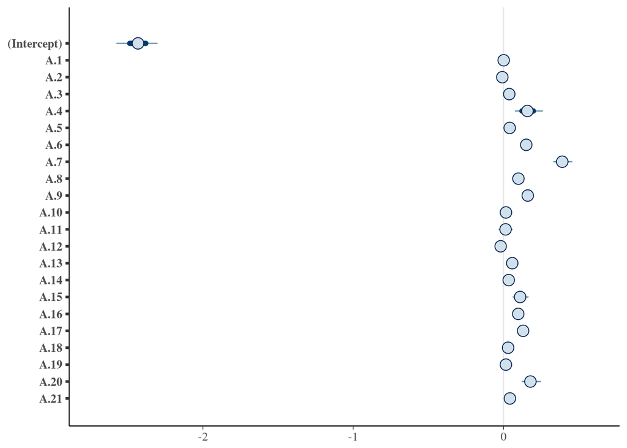

```r
## not run; only makes sense in interactive environment
## launch_shinystan(fit1)

plot(fit1)
```

[figure not shown]

[figure not shown]

[figure not shown]

[figure not shown]

[figure not shown]

[figure not shown]

```r
## not run; only makes sense in interactive environment
## launch_shinystan(fit1)
plot(fit2)
```

# Your Turn: Predict Party Using Bayesian Logistic Regression

1. Fit a logistic regression model predicting political party from votes and generate a confusion matrix to assess the accuracy of the model.
2. Fit a Bayesian logistic regression model predicting political party from votes and generate a confusion matrix to assess the accuracy of the model. You may use either the `MCMCpack` package or the `rstanarm` package.
3. (Advance) Try to find a way of improving upon the classification accuracy obtained in 1 and 2 above.

# General MCMC Programming Environments

Finally we’ve reached level three. Here we specify models in terms of likelihood functions and priors and let our chosen MCMC algorithm search the parameter space.

There are two main options for doing this in R: `R2OpenBUGS` and `rstan`. I’m going to demonstrate `rstan` since I think it is where the current momentum and developer interest currently is.

```r
library(rstan)
## specify model as a charactor vector
model <- '
data {
  int<lower=0>  N;
  vector[N] spam;
  vector[N] A1;
  vector[N] A2;
  vector[N] A3;
  vector[N] A4;
  vector[N] A5;
  vector[N] A6;
  vector[N] A7;
  vector[N] A8;
  vector[N] A9;
  vector[N] A10;
  vector[N] A11;
  vector[N] A12;
  vector[N] A13;
  vector[N] A14;
  vector[N] A15;
  vector[N] A16;
  vector[N] A17;
  vector[N] A18;
  vector[N] A19;
  vector[N] A20;
  vector[N] A21;
}
parameters {
  vector[22] beta;
  real<lower=0> sigma;
}
model {
  spam ~ normal(beta[1] + beta[2] * A1 + beta[3] * A2 + beta[4] * A3
                    + beta[5] * A4 + beta[6] * A5 + beta[7] * A6
                    + beta[8] * A7 + beta[9] * A8
                    + beta[10] * A9 + beta[11] * A10
                    + beta[12] * A11 + beta[13] * A12
                    + beta[14] * A13 + beta[15] * A14
                    + beta[16] * A15 + beta[17] * A16
                    + beta[18] * A17 + beta[19] * A18
                    + beta[20] * A19 + beta[21] * A20
                    + beta[22] * A21,sigma);
}
'

## write model specification to file
cat(model, file = "spamModel.stan")


## prepair data (stan is picky...)
train$spam <- as.integer(train$spam) - 1
## stan doesn't like dots in variable names
names(train) <- gsub("\\.", "", names(train))
train.stan <- c(list(N = nrow(train)), as.list(train))

## fit the model
fit1b <- stan(file = "spamModel.stan",
              data = train.stan)
```

[output not shown]

```r
print(fit1)
```

```
## stan_glm(formula = spam ~ ., family = binomial(link = "logit"),
##     data = test)
##
## Estimates:
##             Median MAD_SD
## (Intercept) -2.4    0.1
## A.1          0.0    0.0
## A.2          0.0    0.0
## A.3          0.0    0.0
## A.4          0.2    0.1
## A.5          0.0    0.0
## A.6          0.2    0.0
## A.7          0.4    0.0
## A.8          0.1    0.0
## A.9          0.2    0.0
## A.10         0.0    0.0
## A.11         0.0    0.0
## A.12         0.0    0.0
## A.13         0.1    0.0
## A.14         0.0    0.0
## A.15         0.1    0.0
## A.16         0.1    0.0
## A.17         0.1    0.0
## A.18         0.0    0.0
## A.19         0.0    0.0
## A.20         0.2    0.0
## A.21         0.0    0.0
##
## Sample avg. posterior predictive
## distribution of y (X = xbar):
##          Median MAD_SD
## mean_PPD 0.4    0.0
```

```
## 'pars' not specified. Showing first 10 parameters by default.
```

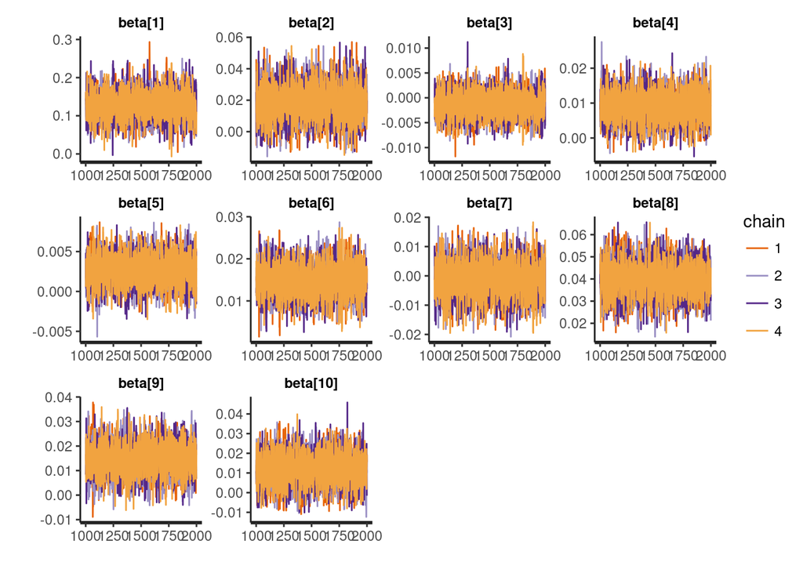

```r
## plot the trace
traceplot(fit1b)
```

```
## 'pars' not specified. Showing first 10 parameters by default.
```

```
## ci_level: 0.8 (80% intervals)
```

```
## outer_level: 0.95 (95% intervals)
```

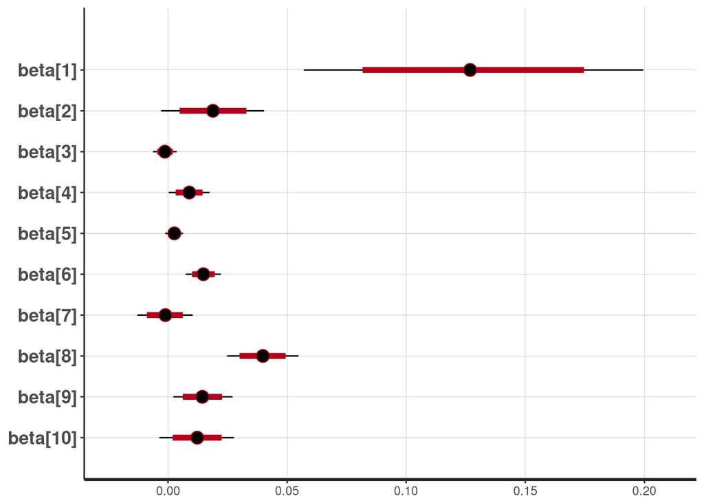

```r
## plot parameters
plot(fit1b)
```

More information about Stan can be found at http://mc-stan.org.